# Chapter 1 : Data Analysis using R

Vinayak Raja

January 26, 2018

## R Markdown

**R Markdown files** are designed to be used in three ways:

a.) communicating to decision makers, who want to focus on the conclusions, not the code behind the analysis.

b.) For collaborating with other data scientists (including future you!), who are interested in both your conclusions, and how you reached them (i.e. the code).

c.) As an environment in which to do data science, as a modern day lab notebook where you can capture not only what you did, but also what you were thinking.

```r
library(data.table) # best package for reading data in any format( pandas equivalent for some functions in Python )
library(RODBC)# Similar to Pyodbc for connecting to terdata or any DB with ODBC
library(tcltk)# small applet to create application exampl:-password app
library(sqldf)# manipulating dataframe with sql code if you dont want DPLY
library(dplyr) # data manipulation library ( everything is based on it:- Pandas was inspired by this)
library(ggplot2)# for data visualization ( you can do anything like )
library(MASS) # provides some statistcal functions
library(corrplot)# making coorelation plot
```

## Major R Packages

The sheer power of R lies in its incredible packages. In R, most data handling tasks can be performed in 2 ways: Using R packages and R base functions.

**To install a package, simply type:** ‘r install.packages(“package name”)’

**Importing Data:** R offers wide range of packages for importing data available in any format such as .txt, .csv, .json, .sql etc. To import large files of data quickly, it is advisable to install and use data.table, readr, RMySQL, sqldf, jsonlite.

**Data Visualization:** R has in built plotting commands as well. They are good to create simple graphs. But, becomes complex when it comes to creating advanced graphics. Hence, you should install ggplot2.

**Data Manipulation:** R has a fantastic collection of packages for data manipulation. These packages allows you to do basic & advanced computations quickly. These packages are dplyr, plyr, tidyr, lubridate, stringr.

**Modeling / Machine Learning:** For modeling, caret package in R is powerful enough to cater to every need for creating machine learning model. However, you can install packages algorithms wise such as randomForest, rpart, gbm etc

```r
# Setting the Working directory
setwd("C:\\Users\\vraja\\Desktop\\Vinayak\\Whitepapers\\R MLDatascience")


#loading the data
pokemon<-fread("https://raw.githubusercontent.com/vinayakraja/Datasets/master/pokemon.csv")
#Reading from computer
#ostk_df<-read.csv("white_csv.csv", stringsAsFactors = FALSE)
```

## Data Types in R

#### R has various type of ‘data types’ which includes vector (numeric, integer etc), matrices, data frames and list.

Everything you see or create in R is an object. A vector, matrix, data frame, even a variable is an object. R treats it that way. So, R has 5 basic classes of objects. This includes:

- Character( super set of Factors)
- Numeric (Real Numbers)
- Integer (Whole Numbers)
- Complex
- Logical (True / False)

**Vector:** Vector contains object of same class. But, you can mix objects of different classes too. When objects of different classes are mixed in a list, coercion occurs. This effect causes the objects of different types to ‘convert’ into one class. For example:

*qt <- c(“Time”, 24, “October”, TRUE, 3.33) #character*

**List:** A list is a special type of vector which contain elements of different data types. For example:

*my_list <- list(22, “ab”, TRUE, 1 + 2i)* use this in R console

**Matrices:** When a vector is introduced with row and column i.e. a dimension attribute, it becomes a matrix. Let’s create a matrix of 3 rows and 2 columns:

*my_matrix <- matrix(1:6, nrow=3, ncol=2)* The dimensions of a matrix can be obtained using either dim() or attributes() command. Example:

*dim(my_matrix) or attributes(my_matrix)*

**You can also join two vectors using cbind()( consider them as Join) and rbind()( consider them as union) functions.**

**Data Frame:** This is the most commonly used member of data types family. It is used to store tabular data. It is different from matrix. In a matrix, every element must have same class. But, in a data frame, you can put list of vectors containing different classes.

## Understanding the data

##### check dimesions ( number of row & columns) in data set

```r
dim(pokemon)
```

```
## [1] 800  12
```

##### column name

```r
names(pokemon)
```

```
##  [1] "#"          "Name"       "Type 1"     "Type 2"     "HP"
##  [6] "Attack"     "Defense"    "Sp. Atk"    "Sp. Def"    "Speed"
## [11] "Generation" "Legendary"
```

##### check the variables and their types in dataset```

```r
str(pokemon)
```

```
## Classes 'data.table' and 'data.frame':   800 obs. of  12 variables:
##  $ #         : int  1 2 3 4 5 6 7 8 9 10 ...
##  $ Name      : chr  "Bulbasaur" "Ivysaur" "Venusaur" "Mega Venusaur" ...
##  $ Type 1    : chr  "Grass" "Grass" "Grass" "Grass" ...
##  $ Type 2    : chr  "Poison" "Poison" "Poison" "Poison" ...
##  $ HP        : int  45 60 80 80 39 58 78 78 78 44 ...
##  $ Attack    : int  49 62 82 100 52 64 84 130 104 48 ...
##  $ Defense   : int  49 63 83 123 43 58 78 111 78 65 ...
##  $ Sp. Atk   : int  65 80 100 122 60 80 109 130 159 50 ...
##  $ Sp. Def   : int  65 80 100 120 50 65 85 85 115 64 ...
##  $ Speed     : int  45 60 80 80 65 80 100 100 100 43 ...
##  $ Generation: int  1 1 1 1 1 1 1 1 1 1 ...
##  $ Legendary : logi  FALSE FALSE FALSE FALSE FALSE FALSE ...
##  - attr(*, ".internal.selfref")=<externalptr>
```

##### Reading the head ( or top 6 rows)

```r
head(pokemon)
```

```
##    #          Name Type 1 Type 2 HP Attack Defense Sp. Atk Sp. Def Speed
## 1: 1     Bulbasaur  Grass Poison 45     49      49      65      65    45
## 2: 2       Ivysaur  Grass Poison 60     62      63      80      80    60
## 3: 3      Venusaur  Grass Poison 80     82      83     100     100    80
## 4: 4 Mega Venusaur  Grass Poison 80    100     123     122     120    80
## 5: 5    Charmander   Fire        39     52      43      60      50    65
## 6: 6    Charmeleon   Fire        58     64      58      80      65    80
##    Generation Legendary
## 1:          1     FALSE
## 2:          1     FALSE
## 3:          1     FALSE
## 4:          1     FALSE
## 5:          1     FALSE
## 6:          1     FALSE
```

##### getting the summary stats in R

```r
summary(pokemon)
```

```
##        #             Name              Type 1             Type 2
##  Min.   :  1.0   Length:800         Length:800         Length:800
##  1st Qu.:200.8   Class :character   Class :character   Class :character
##  Median :400.5   Mode  :character   Mode  :character   Mode  :character
##  Mean   :400.5
##  3rd Qu.:600.2
##  Max.   :800.0
##        HP             Attack       Defense          Sp. Atk
##  Min.   :  1.00   Min.   :  5   Min.   :  5.00   Min.   : 10.00
##  1st Qu.: 50.00   1st Qu.: 55   1st Qu.: 50.00   1st Qu.: 49.75
##  Median : 65.00   Median : 75   Median : 70.00   Median : 65.00
##  Mean   : 69.26   Mean   : 79   Mean   : 73.84   Mean   : 72.82
##  3rd Qu.: 80.00   3rd Qu.:100   3rd Qu.: 90.00   3rd Qu.: 95.00
##  Max.   :255.00   Max.   :190   Max.   :230.00   Max.   :194.00
##     Sp. Def          Speed          Generation    Legendary
##  Min.   : 20.0   Min.   :  5.00   Min.   :1.000   Mode :logical
##  1st Qu.: 50.0   1st Qu.: 45.00   1st Qu.:2.000   FALSE:735
##  Median : 70.0   Median : 65.00   Median :3.000   TRUE :65
##  Mean   : 71.9   Mean   : 68.28   Mean   :3.324   NA's :0
##  3rd Qu.: 90.0   3rd Qu.: 90.00   3rd Qu.:5.000
##  Max.   :230.0   Max.   :180.00   Max.   :6.000
```

##### Finding Missing values

```r
table(is.na(pokemon))
```

```
##
## FALSE
##  9600
```

##### Getting the missing value count

```r
colSums(is.na(pokemon))
```

```
##          #       Name     Type 1     Type 2         HP     Attack
##          0          0          0          0          0          0
##    Defense    Sp. Atk    Sp. Def      Speed Generation  Legendary
##          0          0          0          0          0          0
```

### CORRELATION

**The value of CORRELATION COEFFICIENT is always between +1 and -1. To interpret its value, see which of the following values your correlation is closest to:**

> **Exactly -1** A perfect downhill (negative) linear relationship

> **-0.70** A strong downhill (negative) linear relationship

> **-0.50** A moderate downhill (negative) relationship

> **-0.30** A weak downhill (negative) linear relationship

> **0** No linear relationship

> **+0.30** A weak uphill (positive) linear relationship

> **+0.50** A moderate uphill (positive) relationship

> **+0.70** A strong uphill (positive) linear relationship

> **Exactly +1** A perfect uphill (positive) linear relationship

**However, you can take the idea of no linear relationship two ways:**

1. If no relationship at all exists, calculating the correlation doesn’t make sense because correlation only applies to linear relationships.
2. If a strong relationship exists but it’s not linear, the correlation may be misleading, because in some cases a strong curved relationship exists. That’s why it’s critical to examine the scatterplot first.

#### Building CORRELATION Plot

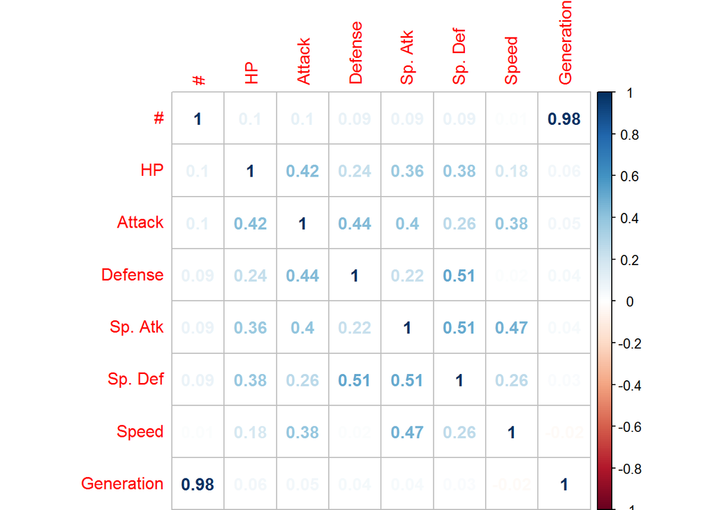

```r
poke<- as.data.frame(pokemon)
cor_df <- poke[ sapply(pokemon, is.numeric)]
corelation<-cor(cor_df)

corrplot(corelation, method="number")
```